# Latihan Pembangkitan ARMA - MPDW Praktikum Pertemuan 4

G1401211094 Hanifa Rahmacindia Nasution

2023-09-21

# Pembangkitan Data sebanyak 300 data

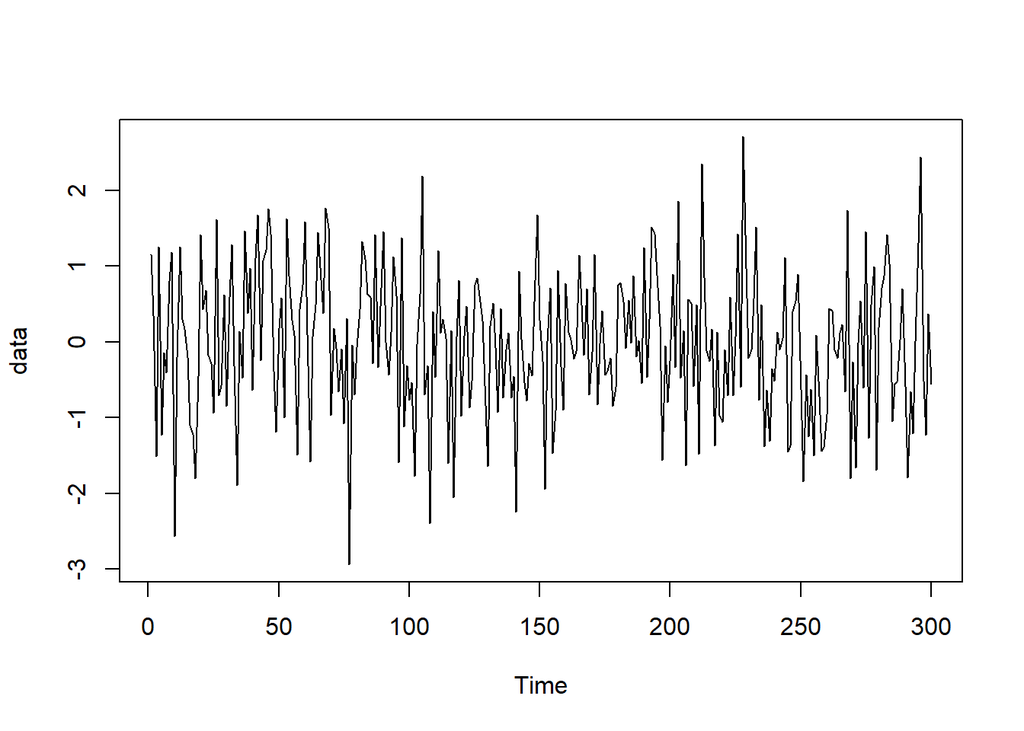

```r
#Cara Manual
set.seed(094)

data <- rnorm(300)
ts.plot(data)
```

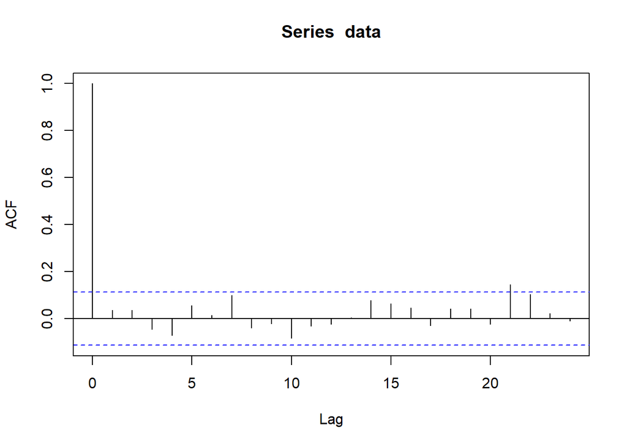

```r
acf(data)
```

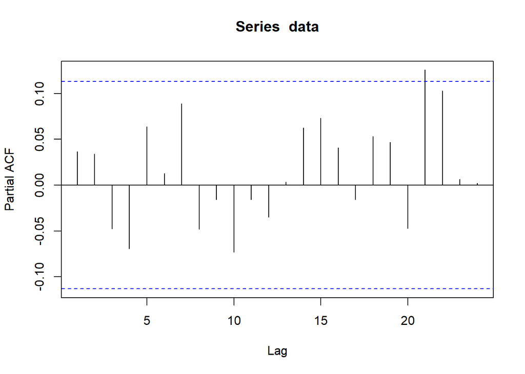

```r
pacf(data)
```

Tampak bahwa pola data tampak stasioner dalam rataan

## Pembentukan Model MA(2) dengan theta1 = 0,4 dan theta2 = 0,6

### Pembentukan Model MA(2) Secara Manual

```r
n = length(data)
theta1 = 0.4
theta2 = 0.6

ma_manual <- data[c(1,2)]
for(i in 3:300){
   ma_manual[i] <- data[i] + 0.4 * data[i - 1] + 0.6 * data[i - 2]
}
ma_manual
```

```
##   [1]  1.151524749  0.346260365 -0.676354863  0.860138407 -1.625759327
##   [6]  0.126393933 -1.190576859  0.555691726  1.264223814 -1.606888149
##  [11] -0.512375552 -0.365069005  0.682300717  1.037466876  0.041736709
##  [16] -1.082809234 -1.784693567 -2.944711907 -1.908647849  0.151098284
##  [21]  0.717628784  1.703546129  0.353852038  0.060808599 -1.154936174
##  [26]  1.075198637 -0.618654481  0.115206746 -0.033466490 -0.944377889
##  [31]  0.625783039  1.011269986  0.558888234 -1.245041696 -0.806101993
##  [36] -1.551694899  1.354121302  0.681905675  1.998717343 -0.016078842
##  [41]  1.428475690  1.741415473  1.093901935  1.987851531  1.500202719
##  [46]  2.889976672  2.858471903  1.247525039 -0.482628114 -0.524217154
##  [51] -0.061891783 -0.660336347  1.572210356  0.924483309  1.619389738
##  [56]  0.733154813 -1.278322314 -0.109857917  0.034068094  2.147888491
##  [61]  1.185147165 -0.590819945 -0.509421628 -0.431709435  1.685422766
##  [66]  1.697216400  1.579156982  2.417467330  2.442607568  0.697605869
##  [71]  0.696113193 -0.587696974 -0.577677964 -0.402571457 -1.501464297
```

[output cut: 45 more lines]

### Pembentukan Model MA(2) Menggunakan Fungsi *arima.sim*

```r
#Pakai Fungsi arima.sim
set.seed(094)
ma2 <- arima.sim(list(order=c(0,0,2), ma=c(0.4,0.6)), n=300)
ma2
```

```
## Time Series:
## Start = 1
## End = 300
## Frequency = 1
##   [1] -0.676354863  0.860138407 -1.625759327  0.126393933 -1.190576859
##   [6]  0.555691726  1.264223814 -1.606888149 -0.512375552 -0.365069005
##  [11]  0.682300717  1.037466876  0.041736709 -1.082809234 -1.784693567
##  [16] -2.944711907 -1.908647849  0.151098284  0.717628784  1.703546129
##  [21]  0.353852038  0.060808599 -1.154936174  1.075198637 -0.618654481
##  [26]  0.115206746 -0.033466490 -0.944377889  0.625783039  1.011269986
##  [31]  0.558888234 -1.245041696 -0.806101993 -1.551694899  1.354121302
##  [36]  0.681905675  1.998717343 -0.016078842  1.428475690  1.741415473
##  [41]  1.093901935  1.987851531  1.500202719  2.889976672  2.858471903
##  [46]  1.247525039 -0.482628114 -0.524217154 -0.061891783 -0.660336347
##  [51]  1.572210356  0.924483309  1.619389738  0.733154813 -1.278322314
```

[output cut: 49 more lines]

### Plot Time Series MA(2)

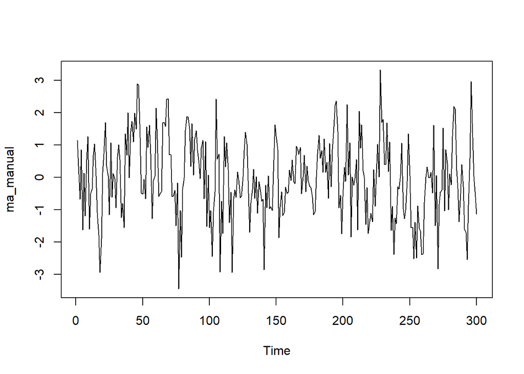

```r
ts.plot(ma_manual)
```

### Plot ACF MA(2)

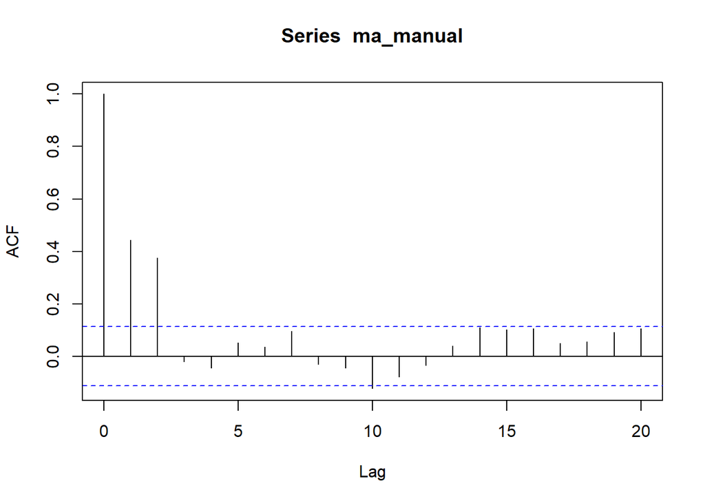

```r
acf(ma_manual, lag.max = 20)
```

Berdasarkan plot ACF tersebut, terlihat bahwa plot ACF *cuts off* pada lag kedua, sejalan dengan teori yang ada

### Plot PACF MA(2)

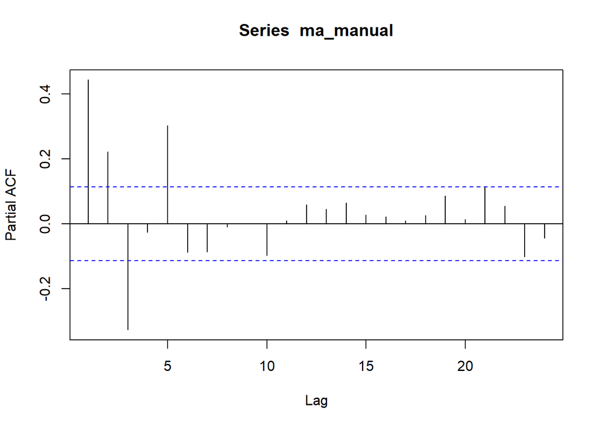

```r
pacf(ma_manual)
```

Berdasarkan plot PACF, terlihat plot PACF tails off dengan bentuk gelombang sinus

### Plot EACF MA(2)

```r
TSA::eacf(ma_manual)
```

```
## AR/MA
##   0 1 2 3 4 5 6 7 8 9 10 11 12 13
## 0 x x o o o o o o o x o  o  o  o
## 1 x x x o o o o o o o o  o  o  o
## 2 x x x o o o o o o o o  o  o  o
## 3 o x x o x o o o o o o  o  o  o
## 4 o x x x x o o o o o o  o  o  o
## 5 x x x x x o o o o o o  o  o  o
## 6 x x o o x x x o o o o  o  o  o
## 7 o o o x x x o o o o o  o  o  o
```

Berdasarkan pola segitiga nol pada plot EACF, terlihat bahwa segitiga nol berada pada ordo AR(0) dan ordo MA(2)

Berdasarkan plot time series yang menunjukkan bergerak di nilai yang sama dan plot PACF yang membentuk gelombang sinus maka dapat diindikasikan data tersebut stasioner

### Scatterplot Model MA(2) antara Yt dengan Yt-1, Yt dengan Yt-2, dan Yt dengan Yt-3

#### Scatterplot Model MA(2) antara Yt dengan Yt-1

```r
#Data untuk Yt dengan Yt-1
#Yt
yt_ma1 <- ma_manual[-1]
yt_ma1
```

```
##   [1]  0.346260365 -0.676354863  0.860138407 -1.625759327  0.126393933
##   [6] -1.190576859  0.555691726  1.264223814 -1.606888149 -0.512375552
##  [11] -0.365069005  0.682300717  1.037466876  0.041736709 -1.082809234
##  [16] -1.784693567 -2.944711907 -1.908647849  0.151098284  0.717628784
##  [21]  1.703546129  0.353852038  0.060808599 -1.154936174  1.075198637
##  [26] -0.618654481  0.115206746 -0.033466490 -0.944377889  0.625783039
##  [31]  1.011269986  0.558888234 -1.245041696 -0.806101993 -1.551694899
##  [36]  1.354121302  0.681905675  1.998717343 -0.016078842  1.428475690
##  [41]  1.741415473  1.093901935  1.987851531  1.500202719  2.889976672
##  [46]  2.858471903  1.247525039 -0.482628114 -0.524217154 -0.061891783
##  [51] -0.660336347  1.572210356  0.924483309  1.619389738  0.733154813
##  [56] -1.278322314 -0.109857917  0.034068094  2.147888491  1.185147165
##  [61] -0.590819945 -0.509421628 -0.431709435  1.685422766  1.697216400
##  [66]  1.579156982  2.417467330  2.442607568  0.697605869  0.696113193
##  [71] -0.587696974 -0.577677964 -0.402571457 -1.501464297 -0.171382963
```

[output cut: 45 more lines]

```r
#Yt-1
yt_1_ma <- ma_manual[-300]
yt_1_ma
```

```
##   [1]  1.151524749  0.346260365 -0.676354863  0.860138407 -1.625759327
##   [6]  0.126393933 -1.190576859  0.555691726  1.264223814 -1.606888149
##  [11] -0.512375552 -0.365069005  0.682300717  1.037466876  0.041736709
##  [16] -1.082809234 -1.784693567 -2.944711907 -1.908647849  0.151098284
##  [21]  0.717628784  1.703546129  0.353852038  0.060808599 -1.154936174
##  [26]  1.075198637 -0.618654481  0.115206746 -0.033466490 -0.944377889
##  [31]  0.625783039  1.011269986  0.558888234 -1.245041696 -0.806101993
##  [36] -1.551694899  1.354121302  0.681905675  1.998717343 -0.016078842
##  [41]  1.428475690  1.741415473  1.093901935  1.987851531  1.500202719
##  [46]  2.889976672  2.858471903  1.247525039 -0.482628114 -0.524217154
##  [51] -0.061891783 -0.660336347  1.572210356  0.924483309  1.619389738
##  [56]  0.733154813 -1.278322314 -0.109857917  0.034068094  2.147888491
##  [61]  1.185147165 -0.590819945 -0.509421628 -0.431709435  1.685422766
##  [66]  1.697216400  1.579156982  2.417467330  2.442607568  0.697605869
##  [71]  0.696113193 -0.587696974 -0.577677964 -0.402571457 -1.501464297
```

[output cut: 45 more lines]

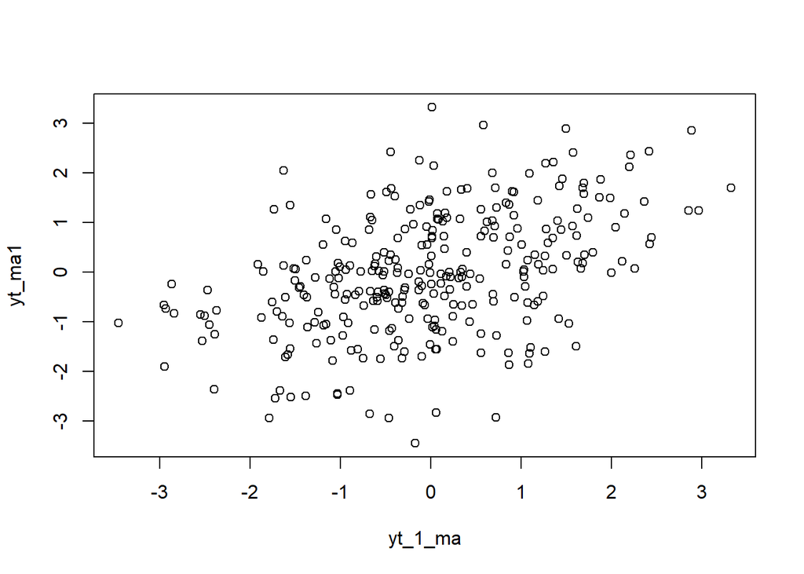

```r
#Scatterplot antara Yt dengan Yt-1
plot(y=yt_ma1,x=yt_1_ma)
```

```r
#Korelasi Yt dengan Yt-1
coryt1ma <- cor(yt_ma1,yt_1_ma)
coryt1ma
```

```
## [1] 0.4445035
```

#### Scatterplot Model MA(2) antara Yt dengan Yt-2

```r
#Data untuk Yt dengan Yt-2
#Yt
yt_ma2 <- ma_manual[-c(1,2)]
yt_ma2
```

```
##   [1] -0.676354863  0.860138407 -1.625759327  0.126393933 -1.190576859
##   [6]  0.555691726  1.264223814 -1.606888149 -0.512375552 -0.365069005
##  [11]  0.682300717  1.037466876  0.041736709 -1.082809234 -1.784693567
##  [16] -2.944711907 -1.908647849  0.151098284  0.717628784  1.703546129
##  [21]  0.353852038  0.060808599 -1.154936174  1.075198637 -0.618654481
##  [26]  0.115206746 -0.033466490 -0.944377889  0.625783039  1.011269986
##  [31]  0.558888234 -1.245041696 -0.806101993 -1.551694899  1.354121302
##  [36]  0.681905675  1.998717343 -0.016078842  1.428475690  1.741415473
##  [41]  1.093901935  1.987851531  1.500202719  2.889976672  2.858471903
##  [46]  1.247525039 -0.482628114 -0.524217154 -0.061891783 -0.660336347
##  [51]  1.572210356  0.924483309  1.619389738  0.733154813 -1.278322314
##  [56] -0.109857917  0.034068094  2.147888491  1.185147165 -0.590819945
##  [61] -0.509421628 -0.431709435  1.685422766  1.697216400  1.579156982
##  [66]  2.417467330  2.442607568  0.697605869  0.696113193 -0.587696974
##  [71] -0.577677964 -0.402571457 -1.501464297 -0.171382963 -3.454504034
```

[output cut: 45 more lines]

```r
#Yt-2
yt_2_ma <- ma_manual[-c(299,300)]
yt_2_ma
```

```
##   [1]  1.151524749  0.346260365 -0.676354863  0.860138407 -1.625759327
##   [6]  0.126393933 -1.190576859  0.555691726  1.264223814 -1.606888149
##  [11] -0.512375552 -0.365069005  0.682300717  1.037466876  0.041736709
##  [16] -1.082809234 -1.784693567 -2.944711907 -1.908647849  0.151098284
##  [21]  0.717628784  1.703546129  0.353852038  0.060808599 -1.154936174
##  [26]  1.075198637 -0.618654481  0.115206746 -0.033466490 -0.944377889
##  [31]  0.625783039  1.011269986  0.558888234 -1.245041696 -0.806101993
##  [36] -1.551694899  1.354121302  0.681905675  1.998717343 -0.016078842
##  [41]  1.428475690  1.741415473  1.093901935  1.987851531  1.500202719
##  [46]  2.889976672  2.858471903  1.247525039 -0.482628114 -0.524217154
##  [51] -0.061891783 -0.660336347  1.572210356  0.924483309  1.619389738
##  [56]  0.733154813 -1.278322314 -0.109857917  0.034068094  2.147888491
##  [61]  1.185147165 -0.590819945 -0.509421628 -0.431709435  1.685422766
##  [66]  1.697216400  1.579156982  2.417467330  2.442607568  0.697605869
##  [71]  0.696113193 -0.587696974 -0.577677964 -0.402571457 -1.501464297
```

[output cut: 45 more lines]

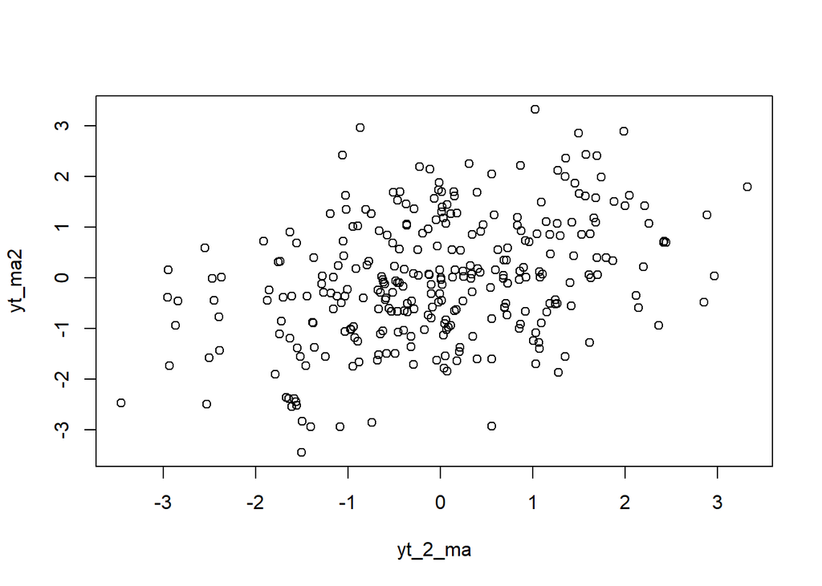

```r
#Scatterplot antara Yt dengan Yt-2
plot(y=yt_ma2,x=yt_2_ma)
```

```r
#Korelasi Yt dengan Yt-2
coryt2ma <- cor(yt_ma2,yt_2_ma)
coryt2ma
```

```
## [1] 0.3762658
```

#### Scatterplot Model MA(2) antara Yt dengan Yt-3

```r
#Data untuk Yt dengan Yt-3
#Yt
yt_ma3 <- ma_manual[-c(1,2,3)]
yt_ma3
```

```
##   [1]  0.860138407 -1.625759327  0.126393933 -1.190576859  0.555691726
##   [6]  1.264223814 -1.606888149 -0.512375552 -0.365069005  0.682300717
##  [11]  1.037466876  0.041736709 -1.082809234 -1.784693567 -2.944711907
##  [16] -1.908647849  0.151098284  0.717628784  1.703546129  0.353852038
##  [21]  0.060808599 -1.154936174  1.075198637 -0.618654481  0.115206746
##  [26] -0.033466490 -0.944377889  0.625783039  1.011269986  0.558888234
##  [31] -1.245041696 -0.806101993 -1.551694899  1.354121302  0.681905675
##  [36]  1.998717343 -0.016078842  1.428475690  1.741415473  1.093901935
##  [41]  1.987851531  1.500202719  2.889976672  2.858471903  1.247525039
##  [46] -0.482628114 -0.524217154 -0.061891783 -0.660336347  1.572210356
##  [51]  0.924483309  1.619389738  0.733154813 -1.278322314 -0.109857917
##  [56]  0.034068094  2.147888491  1.185147165 -0.590819945 -0.509421628
##  [61] -0.431709435  1.685422766  1.697216400  1.579156982  2.417467330
##  [66]  2.442607568  0.697605869  0.696113193 -0.587696974 -0.577677964
##  [71] -0.402571457 -1.501464297 -0.171382963 -3.454504034 -1.027275381
```

[output cut: 45 more lines]

```r
#Yt-3
yt_3_ma <- ma_manual[-c(298,299,300)]
yt_3_ma
```

```
##   [1]  1.151524749  0.346260365 -0.676354863  0.860138407 -1.625759327
##   [6]  0.126393933 -1.190576859  0.555691726  1.264223814 -1.606888149
##  [11] -0.512375552 -0.365069005  0.682300717  1.037466876  0.041736709
##  [16] -1.082809234 -1.784693567 -2.944711907 -1.908647849  0.151098284
##  [21]  0.717628784  1.703546129  0.353852038  0.060808599 -1.154936174
##  [26]  1.075198637 -0.618654481  0.115206746 -0.033466490 -0.944377889
##  [31]  0.625783039  1.011269986  0.558888234 -1.245041696 -0.806101993
##  [36] -1.551694899  1.354121302  0.681905675  1.998717343 -0.016078842
##  [41]  1.428475690  1.741415473  1.093901935  1.987851531  1.500202719
##  [46]  2.889976672  2.858471903  1.247525039 -0.482628114 -0.524217154
##  [51] -0.061891783 -0.660336347  1.572210356  0.924483309  1.619389738
##  [56]  0.733154813 -1.278322314 -0.109857917  0.034068094  2.147888491
##  [61]  1.185147165 -0.590819945 -0.509421628 -0.431709435  1.685422766
##  [66]  1.697216400  1.579156982  2.417467330  2.442607568  0.697605869
##  [71]  0.696113193 -0.587696974 -0.577677964 -0.402571457 -1.501464297
```

[output cut: 45 more lines]

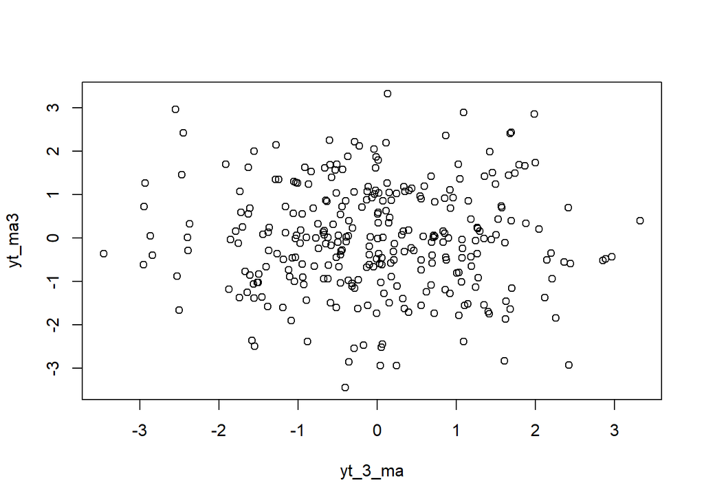

```r
#Scatterplot antara Yt dengan Yt-3
plot(y=yt_ma3,x=yt_3_ma)
```

```r
#Korelasi Yt dengan Yt-3
coryt3ma <- cor(yt_ma3,yt_3_ma)
coryt3ma
```

```
## [1] -0.02151074
```

```r
n = length(data)
phi1 = 0.5
phi2 = 0.2

ar_manual <- data[c(1,2)]
for(i in 3:300){
   ar_manual[i] <- data[i] + 0.5 * data[i - 1] + 0.2 * data[i - 2]
}
ar_manual
```

```
##   [1]  1.1515247491  0.3462603650 -1.1023387263  0.5710568750 -0.8979806101
##   [6] -0.4978999301 -0.7145834196  0.5702554089  1.5046021932 -1.8076320194
##  [11] -1.2426833718  0.6390181499  0.8872938675  0.5672749962 -0.0623560286
##  [16] -1.1698700908 -1.8123891889 -2.6267428076 -1.5998118794  0.8238024146
##  [21]  1.0418145179  1.1815729218  0.2514329794 -0.2310731010 -1.1121920143
##  [26]  1.0934129364 -0.0820923635 -0.6022915838  0.1905780387 -0.6529260498
##  [31]  0.2937243935  1.4095518003  0.4496244784 -1.7889244535 -0.8710501003
##  [36] -0.7819795226  1.2524753228  1.0168249304  1.4522792754 -0.0713457033
##  [41]  0.9773504537  2.1043047901  0.8221726209  1.2916336708  1.7029518307
##  [46]  2.5814874026  2.5491347232  0.6862099943 -1.0911360456 -0.4912977815
##  [51]  0.4306747567 -0.6736169030  1.2407057336  1.4864090662  1.0570863975
##  [56]  0.4130663451 -1.3873453360 -0.2952897840  0.6739977875  2.0505257102
##  [61]  1.0412960725 -1.2155025191 -0.7063788031  0.2072687947  1.7086034873
##  [66]  1.6457832247  1.0813743532  2.1264694248  2.4677602472  0.1394173647
##  [71] -0.0029854537 -0.1825754417 -0.6574823636 -0.4364116229 -1.2492315505
```

[output cut: 45 more lines]

### Pembentukan Model AR(2) Menggunakan Fungsi *arima.sim*

```r
#Pakai Fungsi arima.sim
set.seed(094)
ar2 <- arima.sim(list(order=c(2,0,0), ar=c(0.5,0.2)), n=300)
ar2
```

```
## Time Series:
## Start = 1
## End = 300
## Frequency = 1
##   [1]  1.09718775 -0.35272800 -0.53097438  0.28229387 -0.81232774  0.24399386
##   [7]  1.24168967  0.35944915 -1.46219637 -0.52309012 -1.02597120  0.84364148
##  [13]  0.59722625  1.43707180  0.20565031  1.48980931  2.46702078  1.29323788
##  [19]  2.21457674  2.57925783  3.49246000  3.68859404  2.16375963  0.63267478
##  [25]  0.92705933  1.16913914 -0.22876673  1.74370938  1.70012759  1.49402596
##  [31]  1.17768945 -0.60406495  0.36594287  0.81828048  2.06830602  1.29489217
##  [37] -0.52013220  0.06373666  0.41894642  1.67230690  1.74246187  1.58578983
##  [43]  2.91330413  3.27959235  1.25459984  1.46300505  0.90352515  0.09037256
##  [49]  0.13225467 -0.98741318 -0.15381062 -3.21130098 -1.67698980 -2.17207831
##  [55] -1.48813375 -0.74911653  0.65499591  1.27441654  1.40347409  1.54763902
##  [61]  0.77708513  2.11730152  0.88482292  1.33390573  2.29805476  1.41236421
```

[output cut: 39 more lines]

### Plot Time Series AR(2)

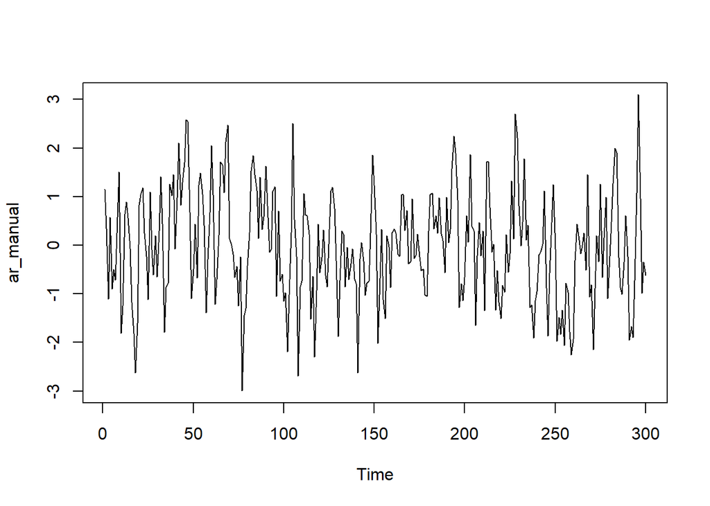

```r
ts.plot(ar_manual)
```

Berdasarkan plot time series, tampak bahwa pola data AR(2) stasioner dalam rataan

### Plot ACF AR(2)

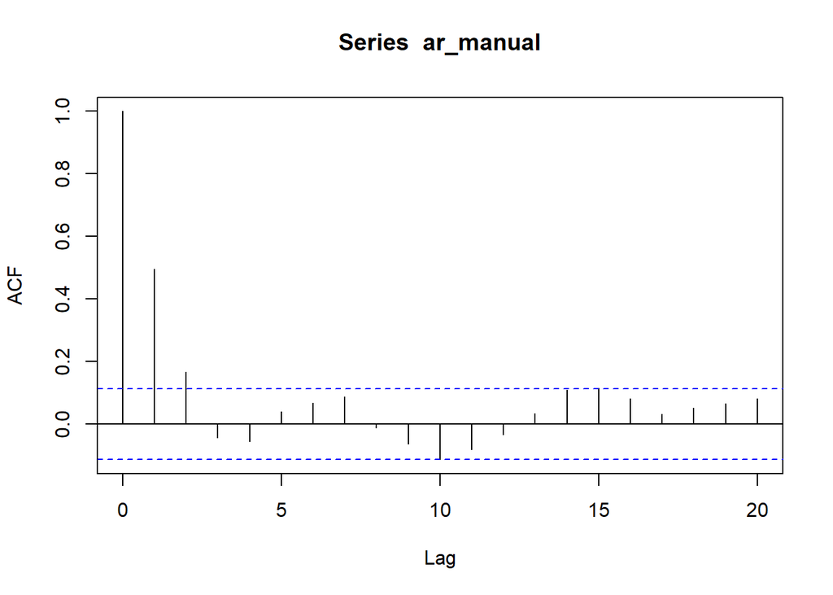

```r
acf(ar_manual, lag.max = 20)
```

### Plot PACF AR(2)

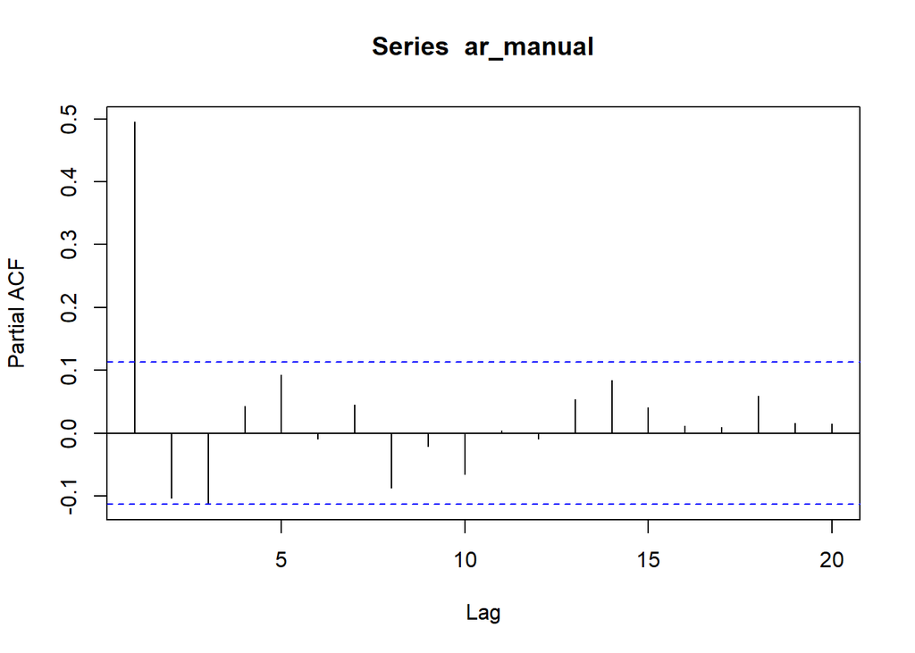

```r
pacf(ar_manual, lag.max = 20)
```

### Plot EACF AR(2)

```r
TSA::eacf(ar_manual)
```

```
## AR/MA
##   0 1 2 3 4 5 6 7 8 9 10 11 12 13
## 0 x x o o o o o o o o o  o  o  o
## 1 x x x o o o o o o o o  o  o  o
## 2 x x o o o o o o o o o  o  o  o
## 3 x x o o x o o o o o o  o  o  o
## 4 x x o o x o o o o o o  o  o  o
## 5 o x x x x o o o o o o  o  o  o
## 6 x o x o o o o o o o o  o  o  o
## 7 x o x x o x o o o o o  o  o  o
```

### Buat Scatterplot Model AR(2) antara Yt dengan Yt-1, Yt dengan Yt-2, dan Yt dengan Yt-3

#### Buat Scatterplot Model AR(2) antara Yt dengan Yt-1

```r
#Data untuk Yt dengan Yt-1
#Yt
yt_ar1 <- ar_manual[-1]
yt_ar1
```

```
##   [1]  0.3462603650 -1.1023387263  0.5710568750 -0.8979806101 -0.4978999301
##   [6] -0.7145834196  0.5702554089  1.5046021932 -1.8076320194 -1.2426833718
##  [11]  0.6390181499  0.8872938675  0.5672749962 -0.0623560286 -1.1698700908
##  [16] -1.8123891889 -2.6267428076 -1.5998118794  0.8238024146  1.0418145179
##  [21]  1.1815729218  0.2514329794 -0.2310731010 -1.1121920143  1.0934129364
##  [26] -0.0820923635 -0.6022915838  0.1905780387 -0.6529260498  0.2937243935
##  [31]  1.4095518003  0.4496244784 -1.7889244535 -0.8710501003 -0.7819795226
##  [36]  1.2524753228  1.0168249304  1.4522792754 -0.0713457033  0.9773504537
##  [41]  2.1043047901  0.8221726209  1.2916336708  1.7029518307  2.5814874026
##  [46]  2.5491347232  0.6862099943 -1.0911360456 -0.4912977815  0.4306747567
##  [51] -0.6736169030  1.2407057336  1.4864090662  1.0570863975  0.4130663451
##  [56] -1.3873453360 -0.2952897840  0.6739977875  2.0505257102  1.0412960725
##  [61] -1.2155025191 -0.7063788031  0.2072687947  1.7086034873  1.6457832247
##  [66]  1.0813743532  2.1264694248  2.4677602472  0.1394173647 -0.0029854537
##  [71] -0.1825754417 -0.6574823636 -0.4364116229 -1.2492315505 -0.2410898083
```

[output cut: 45 more lines]

```r
#Yt-1
yt_1_ar <- ar_manual[-300]
yt_1_ar
```

```
##   [1]  1.1515247491  0.3462603650 -1.1023387263  0.5710568750 -0.8979806101
##   [6] -0.4978999301 -0.7145834196  0.5702554089  1.5046021932 -1.8076320194
##  [11] -1.2426833718  0.6390181499  0.8872938675  0.5672749962 -0.0623560286
##  [16] -1.1698700908 -1.8123891889 -2.6267428076 -1.5998118794  0.8238024146
##  [21]  1.0418145179  1.1815729218  0.2514329794 -0.2310731010 -1.1121920143
##  [26]  1.0934129364 -0.0820923635 -0.6022915838  0.1905780387 -0.6529260498
##  [31]  0.2937243935  1.4095518003  0.4496244784 -1.7889244535 -0.8710501003
##  [36] -0.7819795226  1.2524753228  1.0168249304  1.4522792754 -0.0713457033
##  [41]  0.9773504537  2.1043047901  0.8221726209  1.2916336708  1.7029518307
##  [46]  2.5814874026  2.5491347232  0.6862099943 -1.0911360456 -0.4912977815
##  [51]  0.4306747567 -0.6736169030  1.2407057336  1.4864090662  1.0570863975
##  [56]  0.4130663451 -1.3873453360 -0.2952897840  0.6739977875  2.0505257102
##  [61]  1.0412960725 -1.2155025191 -0.7063788031  0.2072687947  1.7086034873
##  [66]  1.6457832247  1.0813743532  2.1264694248  2.4677602472  0.1394173647
##  [71] -0.0029854537 -0.1825754417 -0.6574823636 -0.4364116229 -1.2492315505
```

[output cut: 45 more lines]

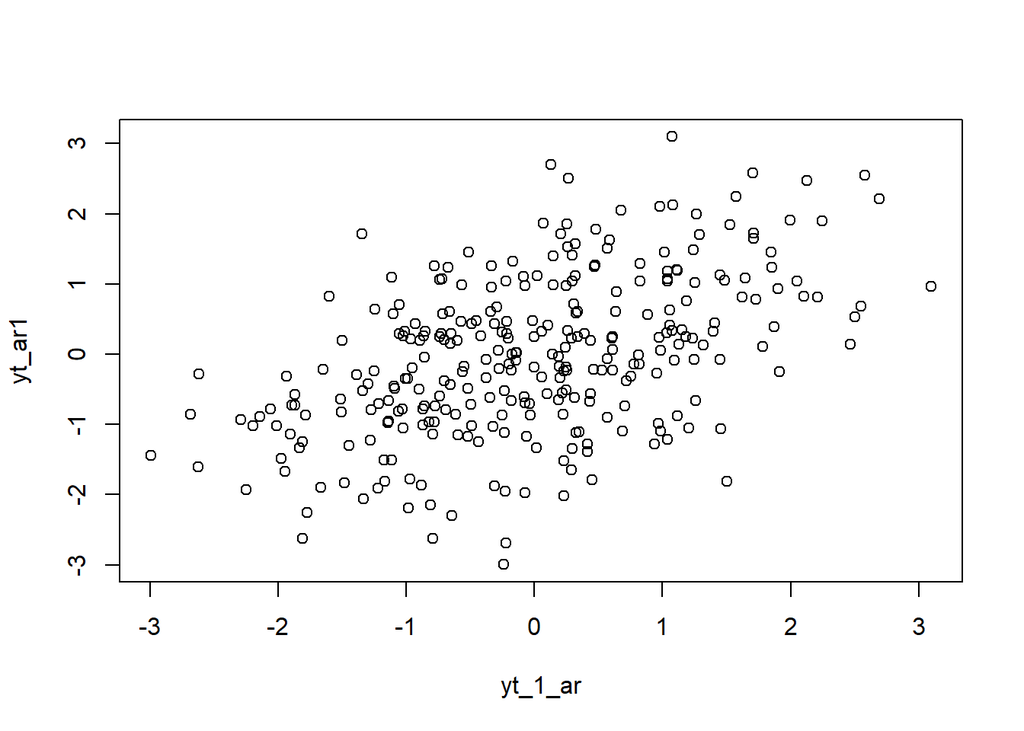

```r
#Scatterplot antara Yt dengan Yt-1
plot(y=yt_ar1,x=yt_1_ar)
```

```r
#Korelasi Yt dengan Yt-1
coryt1ar <- cor(yt_ar1,yt_1_ar)
coryt1ar
```

```
## [1] 0.4961338
```

#### Buat Scatterplot Model AR(2) antara Yt dengan Yt-2

```r
#Data untuk Yt dengan Yt-2
#Yt
yt_ar2 <- ar_manual[-c(1,2)]
yt_ar2
```

```
##   [1] -1.1023387263  0.5710568750 -0.8979806101 -0.4978999301 -0.7145834196
##   [6]  0.5702554089  1.5046021932 -1.8076320194 -1.2426833718  0.6390181499
##  [11]  0.8872938675  0.5672749962 -0.0623560286 -1.1698700908 -1.8123891889
##  [16] -2.6267428076 -1.5998118794  0.8238024146  1.0418145179  1.1815729218
##  [21]  0.2514329794 -0.2310731010 -1.1121920143  1.0934129364 -0.0820923635
##  [26] -0.6022915838  0.1905780387 -0.6529260498  0.2937243935  1.4095518003
##  [31]  0.4496244784 -1.7889244535 -0.8710501003 -0.7819795226  1.2524753228
##  [36]  1.0168249304  1.4522792754 -0.0713457033  0.9773504537  2.1043047901
##  [41]  0.8221726209  1.2916336708  1.7029518307  2.5814874026  2.5491347232
##  [46]  0.6862099943 -1.0911360456 -0.4912977815  0.4306747567 -0.6736169030
##  [51]  1.2407057336  1.4864090662  1.0570863975  0.4130663451 -1.3873453360
##  [56] -0.2952897840  0.6739977875  2.0505257102  1.0412960725 -1.2155025191
##  [61] -0.7063788031  0.2072687947  1.7086034873  1.6457832247  1.0813743532
##  [66]  2.1264694248  2.4677602472  0.1394173647 -0.0029854537 -0.1825754417
##  [71] -0.6574823636 -0.4364116229 -1.2492315505 -0.2410898083 -2.9945135214
```

[output cut: 45 more lines]

```r
#Yt-2
yt_2_ar <- ar_manual[-c(299,300)]
yt_2_ar
```

```
##   [1]  1.1515247491  0.3462603650 -1.1023387263  0.5710568750 -0.8979806101
##   [6] -0.4978999301 -0.7145834196  0.5702554089  1.5046021932 -1.8076320194
##  [11] -1.2426833718  0.6390181499  0.8872938675  0.5672749962 -0.0623560286
##  [16] -1.1698700908 -1.8123891889 -2.6267428076 -1.5998118794  0.8238024146
##  [21]  1.0418145179  1.1815729218  0.2514329794 -0.2310731010 -1.1121920143
##  [26]  1.0934129364 -0.0820923635 -0.6022915838  0.1905780387 -0.6529260498
##  [31]  0.2937243935  1.4095518003  0.4496244784 -1.7889244535 -0.8710501003
##  [36] -0.7819795226  1.2524753228  1.0168249304  1.4522792754 -0.0713457033
##  [41]  0.9773504537  2.1043047901  0.8221726209  1.2916336708  1.7029518307
##  [46]  2.5814874026  2.5491347232  0.6862099943 -1.0911360456 -0.4912977815
##  [51]  0.4306747567 -0.6736169030  1.2407057336  1.4864090662  1.0570863975
##  [56]  0.4130663451 -1.3873453360 -0.2952897840  0.6739977875  2.0505257102
##  [61]  1.0412960725 -1.2155025191 -0.7063788031  0.2072687947  1.7086034873
##  [66]  1.6457832247  1.0813743532  2.1264694248  2.4677602472  0.1394173647
##  [71] -0.0029854537 -0.1825754417 -0.6574823636 -0.4364116229 -1.2492315505
```

[output cut: 45 more lines]

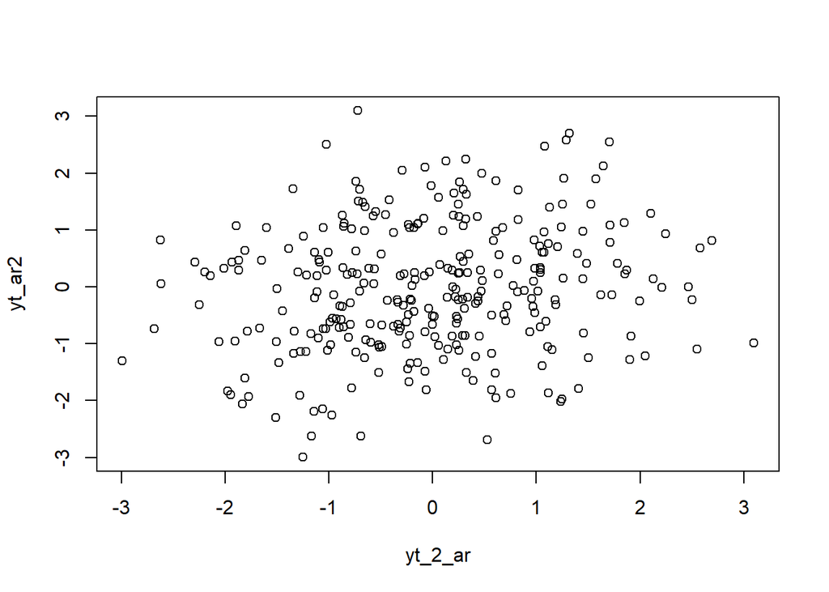

```r
#Scatterplot antara Yt dengan Yt-2
plot(y=yt_ar2,x=yt_2_ar)
```

```r
#Korelasi Yt dengan Yt-2
coryt2ar <- cor(yt_ar2,yt_2_ar)
coryt2ar
```

```
## [1] 0.1671719
```

#### Buat Scatterplot Model AR(2) antara Yt dengan Yt-3

```r
#Data untuk Yt dengan Yt-3
#Yt
yt_ar3 <- ar_manual[-c(1,2,3)]
yt_ar3
```

```
##   [1]  0.5710568750 -0.8979806101 -0.4978999301 -0.7145834196  0.5702554089
##   [6]  1.5046021932 -1.8076320194 -1.2426833718  0.6390181499  0.8872938675
##  [11]  0.5672749962 -0.0623560286 -1.1698700908 -1.8123891889 -2.6267428076
##  [16] -1.5998118794  0.8238024146  1.0418145179  1.1815729218  0.2514329794
##  [21] -0.2310731010 -1.1121920143  1.0934129364 -0.0820923635 -0.6022915838
##  [26]  0.1905780387 -0.6529260498  0.2937243935  1.4095518003  0.4496244784
##  [31] -1.7889244535 -0.8710501003 -0.7819795226  1.2524753228  1.0168249304
##  [36]  1.4522792754 -0.0713457033  0.9773504537  2.1043047901  0.8221726209
##  [41]  1.2916336708  1.7029518307  2.5814874026  2.5491347232  0.6862099943
##  [46] -1.0911360456 -0.4912977815  0.4306747567 -0.6736169030  1.2407057336
##  [51]  1.4864090662  1.0570863975  0.4130663451 -1.3873453360 -0.2952897840
##  [56]  0.6739977875  2.0505257102  1.0412960725 -1.2155025191 -0.7063788031
##  [61]  0.2072687947  1.7086034873  1.6457832247  1.0813743532  2.1264694248
##  [66]  2.4677602472  0.1394173647 -0.0029854537 -0.1825754417 -0.6574823636
##  [71] -0.4364116229 -1.2492315505 -0.2410898083 -2.9945135214 -1.4463446975
```

[output cut: 45 more lines]

```r
#Yt-3
yt_3_ar <- ar_manual[-c(298,299,300)]
yt_3_ar
```

```
##   [1]  1.1515247491  0.3462603650 -1.1023387263  0.5710568750 -0.8979806101
##   [6] -0.4978999301 -0.7145834196  0.5702554089  1.5046021932 -1.8076320194
##  [11] -1.2426833718  0.6390181499  0.8872938675  0.5672749962 -0.0623560286
##  [16] -1.1698700908 -1.8123891889 -2.6267428076 -1.5998118794  0.8238024146
##  [21]  1.0418145179  1.1815729218  0.2514329794 -0.2310731010 -1.1121920143
##  [26]  1.0934129364 -0.0820923635 -0.6022915838  0.1905780387 -0.6529260498
##  [31]  0.2937243935  1.4095518003  0.4496244784 -1.7889244535 -0.8710501003
##  [36] -0.7819795226  1.2524753228  1.0168249304  1.4522792754 -0.0713457033
##  [41]  0.9773504537  2.1043047901  0.8221726209  1.2916336708  1.7029518307
##  [46]  2.5814874026  2.5491347232  0.6862099943 -1.0911360456 -0.4912977815
##  [51]  0.4306747567 -0.6736169030  1.2407057336  1.4864090662  1.0570863975
##  [56]  0.4130663451 -1.3873453360 -0.2952897840  0.6739977875  2.0505257102
##  [61]  1.0412960725 -1.2155025191 -0.7063788031  0.2072687947  1.7086034873
##  [66]  1.6457832247  1.0813743532  2.1264694248  2.4677602472  0.1394173647
##  [71] -0.0029854537 -0.1825754417 -0.6574823636 -0.4364116229 -1.2492315505
```

[output cut: 45 more lines]

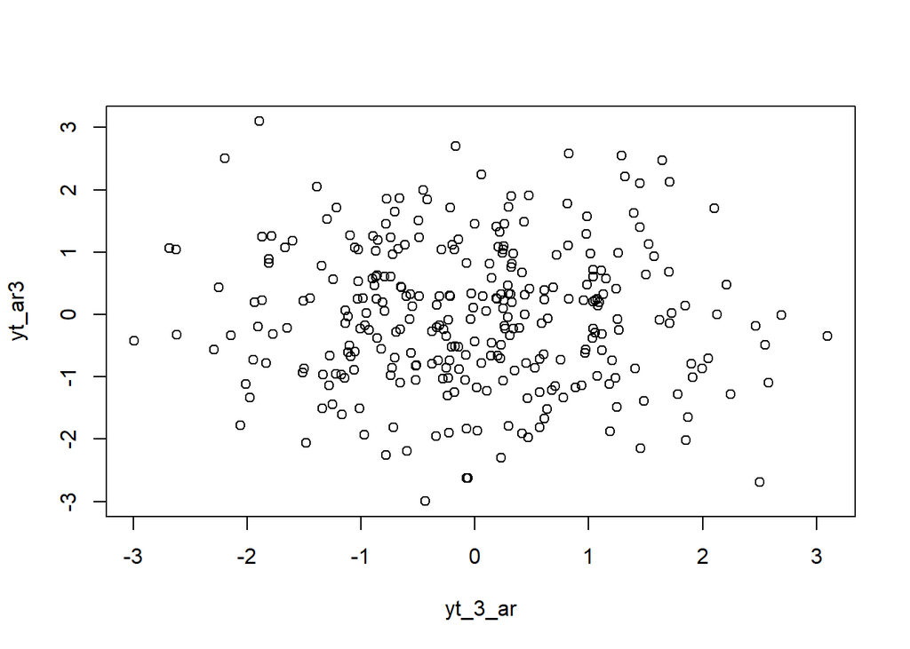

```r
#Scatterplot antara Yt dengan Yt-3
plot(y=yt_ar3,x=yt_3_ar)
```

```r
#Korelasi Yt dengan Yt-3
coryt3ar <- cor(yt_ar3,yt_3_ar)
coryt3ar
```

```
## [1] -0.04510981
```

## Pembentukan Model ARMA(2,2) dengan phi(untuk AR) = 0.5 dan 0.2 dan tetha(untuk MA) = 0.4 dan 0.6

Jika koefisien dan *white noise*/nilai deret waktu sebelumnya dapat diekstrak dalam bentuk vektor, dapat dilakukan perkalian matriks untuk mencari nilai bagian AR dan MA:

```r
coefs <- c(0.4, 0.6, 0.5, 0.2)
e <- c(1, 2, 3, 4)

coefs %*% e
```

```
##      [,1]
## [1,]  3.9
```

Dari prinsip ini, dapat dibuat fungsi umum untuk membangkitkan data ARMA. Input dari fungsi adalah jumlah data yang hendak dibangkitkan, koefisien MA, dan koefisien AR

```r
arma.sim <- function(n, macoef, arcoef){
  manum <- length(macoef)
  arnum <- length(arcoef)
  stopifnot(manum < n & arnum < n)

  wn <- rnorm(n, sd = 0.5)
  init <- max(manum, arnum)

  arma <- data[1:init]
  for(i in {init+1}:n){
   mastart <- i - manum
   maend <- i-1
   arstart <- i - arnum
   arend <- i-1
   arma[i] <- sum(arcoef * arma[arstart:arend]) + sum(macoef * data[mastart:maend])  + data[i]
   }
  return(arma)
}
```

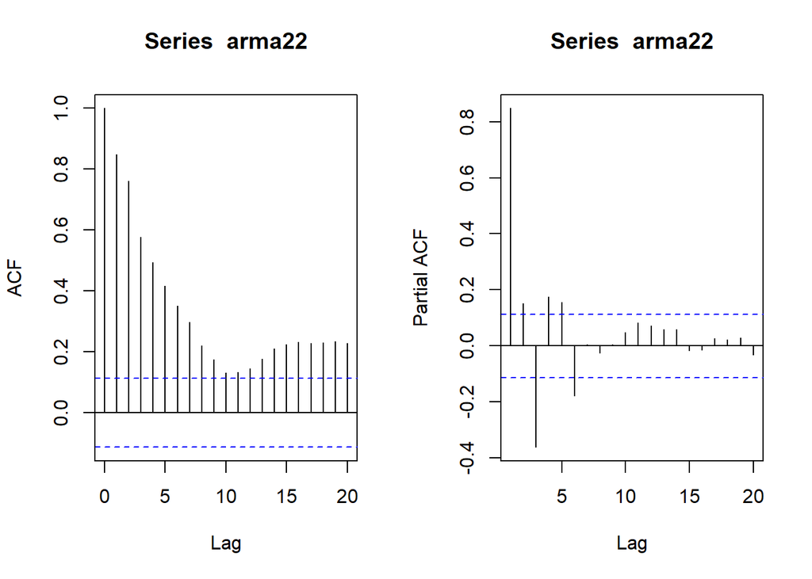

```r
#Contoh pembangkitan data ARMA(2,2) menggunakan fungsi buatan dengan phi1 = 0.5 ; phi2 = 0.2 dan tetha1 = 0.4 ; tetha2 = 0.6
set.seed(094)
arma22 <- arma.sim(300, c(0.4, 0.6), c(0.5,0.2))

par(mfrow = c(1, 2))
acf(arma22,lag.max = 20)
pacf(arma22,lag.max = 20)
```

### Pembentukan Model ARMA (2,2) Secara Manual Menggunakan Fungsi yang Sudah Didefinisikan Sebelumnya

```r
set.seed(094)
n = length(data)
phi1 = 0.5
phi2 = 0.2
theta1 = 0.4
theta2 = 0.6

y.arma=c(1:n)
for (i in 3:n){
  y.arma[i] = phi1*y.arma[i-1]+ phi2*y.arma[i-2] + theta1*data[i-1]+ theta2*data[i-2] +data[i]
  }
```

### Pembentukan Model ARMA(2,2) Menggunakan Fungsi *arima.sim*

Pembangkitan ARMA(p,q) juga dapat dilakukan dengan fungsi `arima.sim` sebagai berikut.

```r
set.seed(094)
arma22 <- arima.sim(list(order=c(2,0,2), ar = c(0.5,0.2), ma = c(0.4,0.6)), n=300)
arma22
```

```
## Time Series:
## Start = 1
## End = 300
## Frequency = 1
##   [1] -0.01483454 -0.14255724 -1.01862342  0.08795988  0.85152524  1.00224283
##   [7] -0.57361523 -0.89246104 -2.11264847  0.11930486  0.31902841  2.18209252
##  [13]  1.13877310  2.43428074  3.18631047  3.17391332  4.21207028  4.24102052
##  [19]  5.85290099  6.63312650  5.73466849  3.71133143  2.47838226  1.91956563
##  [25]  0.79512292  2.35368494  2.26035037  3.22030191  2.79537584  0.76342599
##  [31]  0.83093025  0.60221841  2.61518375  2.61318272  1.23880817  0.63261900
##  [37]  0.13236170  1.87812742  2.66275245  3.28615869  4.59309716  5.39638789
##  [43]  4.31441924  3.93260039  2.24148707  1.32958565  0.71051878 -0.88028778
##  [49] -0.46942309 -3.86527314 -3.05379657 -4.76965482 -3.36315895 -2.64761701
##  [55] -0.53753095  1.08694499  2.30623825  2.87367858  2.23822519  3.35671899
##  [61]  2.19799461  2.95821582  3.36251081  3.13192956  2.67829043  1.92317602
```

[output cut: 39 more lines]

### Karakteristik ARMA(2,2)

#### Plot Time Series ARMA(2,2)

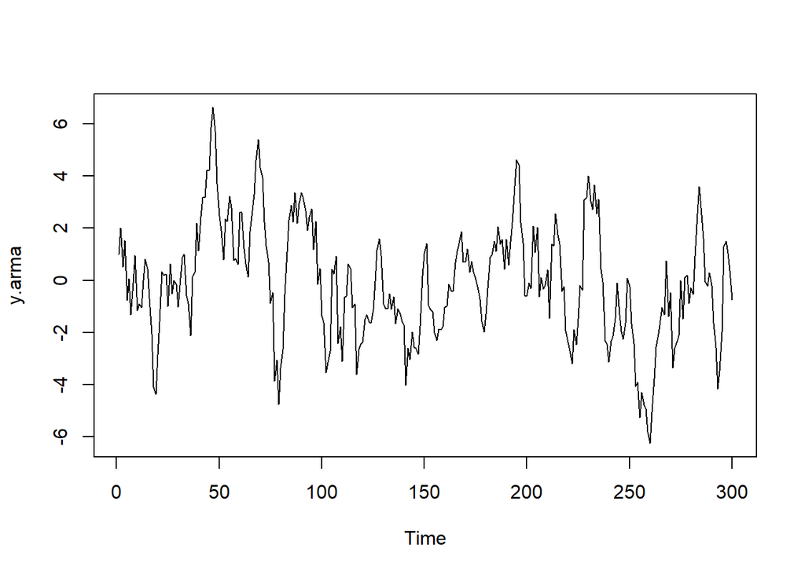

```r
ts.plot(y.arma)
```

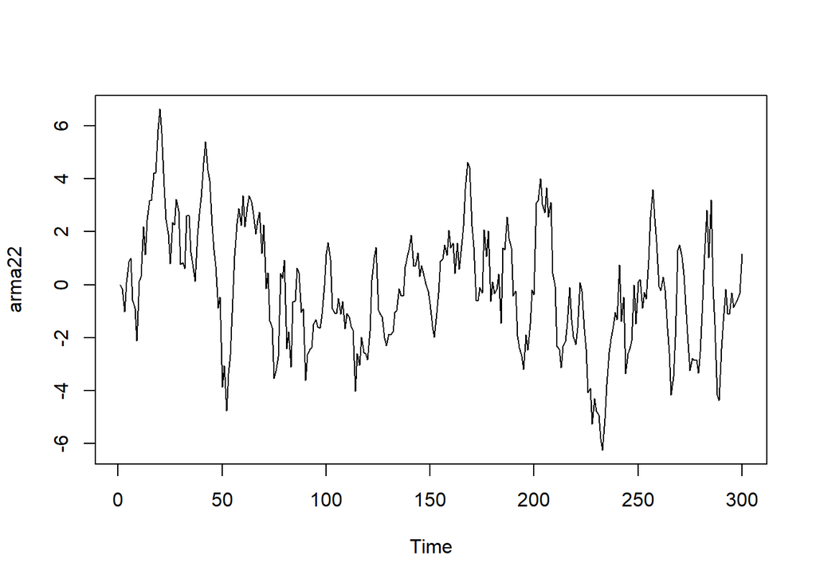

```r
ts.plot(arma22)
```

Berdasarkan plot time series ARMA(2,2), tampak bahwa plot data stasioner dalam rataan

#### Plot ACF ARMA(2,2)

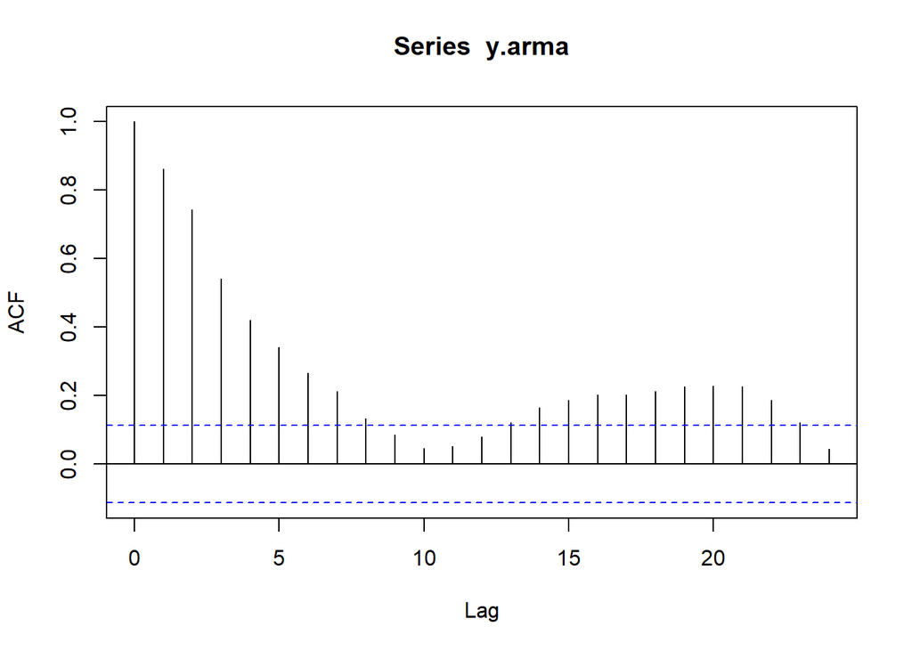

```r
acf(y.arma)
```

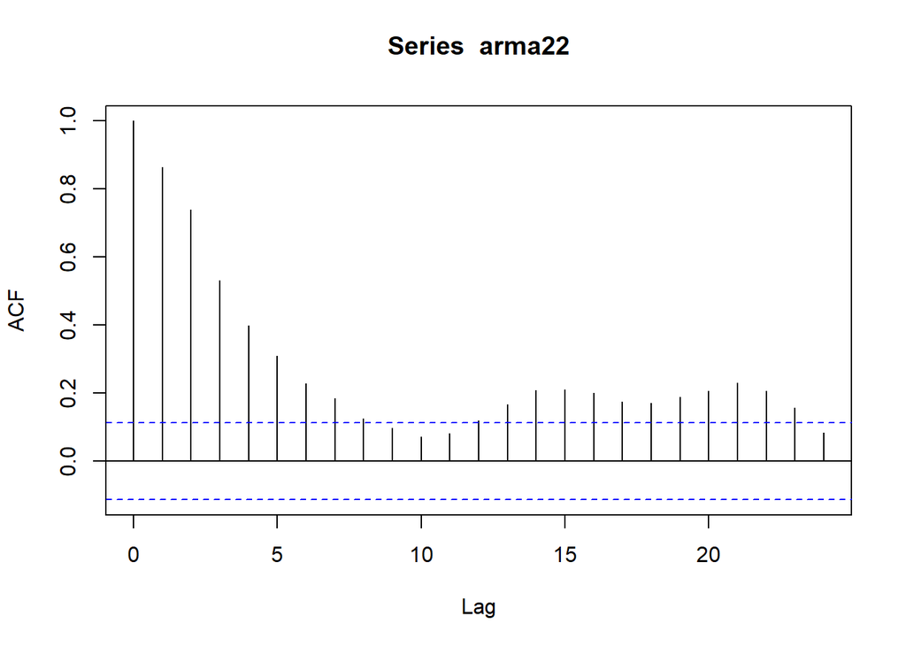

```r
acf(arma22)
```

Berdasarkan plot ACF tersebut, terlihat bahwa model ARMA(2,2) hasil simulasi memiliki plot ACF yang *tails off*, sesuai dengan teori yang ada

#### Plot PACF ARMA(2,2)

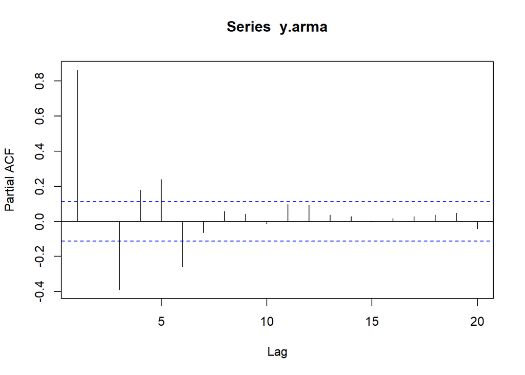

```r
pacf(y.arma,lag.max = 20)
```

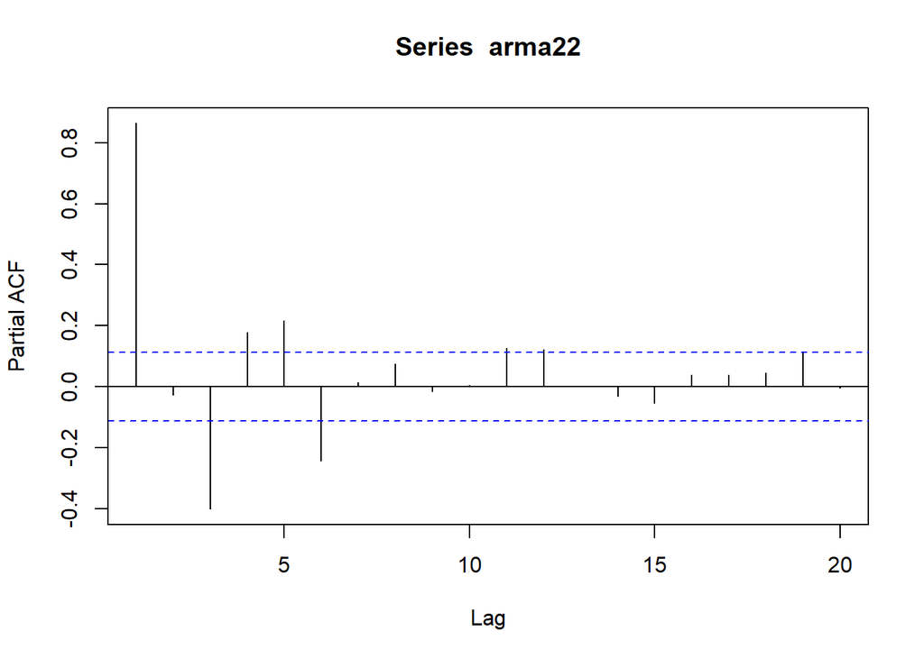

```r
pacf(arma22,lag.max = 20)
```

Berdasarkan plot PACF tersebut, terlihat bahwa model ARMA(2,2) hasil simulasi memiliki plot PACF yang *tails off*, sesuai dengan teori yang ada

#### Plot EACF ARMA(2,2)

```r
TSA::eacf(y.arma)
```

```
## AR/MA
##   0 1 2 3 4 5 6 7 8 9 10 11 12 13
## 0 x x x x x x x x o o o  o  x  x
## 1 o x x o o o x o o x o  o  o  o
## 2 o x x o o o x o o o o  o  o  o
## 3 x x o o o o x o o o o  o  o  o
## 4 x x o o x o o o o o o  o  o  o
## 5 x x o o x o o o o o o  o  o  o
## 6 x x o o x x x o o o o  o  o  o
## 7 x x x o x o x o o o o  o  o  o
```

```r
TSA::eacf(arma22)
```

```
## AR/MA
##   0 1 2 3 4 5 6 7 8 9 10 11 12 13
## 0 x x x x x x x x o o o  x  x  x
## 1 o x o o o o o o o o o  o  o  x
## 2 o x x o o o o o o o o  o  o  x
## 3 x x o o o o o o o o o  o  o  x
## 4 x x x o o o o o o o o  o  o  o
## 5 x x x o o o o o o o o  o  o  o
## 6 o x o o o o x o o o o  o  o  o
## 7 o x x o x o x o o o o  o  o  o
```

Berdasarkan pola segitiga nol pada plot EACF, tidak terlihat bahwa segitiga nol berada pada ordo AR(2) dan ordo MA(2). Pada plot dari fungsi *eacf(arma22)* justru tampak segitiga nol berada pada ordo AR(1) dan ordo MA(2) dimana hasil tersebut tidak sesuai dengan hasil yang diinginkan.

#### Buat Scatterplot Model ARMA(2,2) antara Yt dengan Yt-1, Yt dengan Yt-2, dan Yt dengan Yt-3

##### Buat Scatterplot Model ARMA(2,2) antara Yt dengan Yt-1

```r
#Data untuk Yt dengan Yt-1
#Yt
yt_arma1 <- arma22[-1]
yt_arma1
```

```
##   [1] -0.14255724 -1.01862342  0.08795988  0.85152524  1.00224283 -0.57361523
##   [7] -0.89246104 -2.11264847  0.11930486  0.31902841  2.18209252  1.13877310
##  [13]  2.43428074  3.18631047  3.17391332  4.21207028  4.24102052  5.85290099
##  [19]  6.63312650  5.73466849  3.71133143  2.47838226  1.91956563  0.79512292
##  [25]  2.35368494  2.26035037  3.22030191  2.79537584  0.76342599  0.83093025
##  [31]  0.60221841  2.61518375  2.61318272  1.23880817  0.63261900  0.13236170
##  [37]  1.87812742  2.66275245  3.28615869  4.59309716  5.39638789  4.31441924
##  [43]  3.93260039  2.24148707  1.32958565  0.71051878 -0.88028778 -0.46942309
##  [49] -3.86527314 -3.05379657 -4.76965482 -3.36315895 -2.64761701 -0.53753095
##  [55]  1.08694499  2.30623825  2.87367858  2.23822519  3.35671899  2.19799461
##  [61]  2.95821582  3.36251081  3.13192956  2.67829043  1.92317602  2.41918045
##  [67]  2.73981089  1.18765765  2.25171598 -0.15196604  0.44072143 -1.36753884
##  [73] -1.62598313 -3.53268210 -3.15106707 -2.72337315  0.43325687  0.23304931
##  [79]  0.92577281 -2.42335317 -1.76915084 -3.10476249 -0.64195061 -0.61338408
##  [85]  0.64079220  0.44388593 -1.04879145 -0.89758165 -3.60816485 -2.64756805
```

[output cut: 35 more lines]

```r
#Yt-1
yt_1_arma <- arma22[-300]
yt_1_arma
```

```
##   [1] -0.01483454 -0.14255724 -1.01862342  0.08795988  0.85152524  1.00224283
##   [7] -0.57361523 -0.89246104 -2.11264847  0.11930486  0.31902841  2.18209252
##  [13]  1.13877310  2.43428074  3.18631047  3.17391332  4.21207028  4.24102052
##  [19]  5.85290099  6.63312650  5.73466849  3.71133143  2.47838226  1.91956563
##  [25]  0.79512292  2.35368494  2.26035037  3.22030191  2.79537584  0.76342599
##  [31]  0.83093025  0.60221841  2.61518375  2.61318272  1.23880817  0.63261900
##  [37]  0.13236170  1.87812742  2.66275245  3.28615869  4.59309716  5.39638789
##  [43]  4.31441924  3.93260039  2.24148707  1.32958565  0.71051878 -0.88028778
##  [49] -0.46942309 -3.86527314 -3.05379657 -4.76965482 -3.36315895 -2.64761701
##  [55] -0.53753095  1.08694499  2.30623825  2.87367858  2.23822519  3.35671899
##  [61]  2.19799461  2.95821582  3.36251081  3.13192956  2.67829043  1.92317602
##  [67]  2.41918045  2.73981089  1.18765765  2.25171598 -0.15196604  0.44072143
##  [73] -1.36753884 -1.62598313 -3.53268210 -3.15106707 -2.72337315  0.43325687
##  [79]  0.23304931  0.92577281 -2.42335317 -1.76915084 -3.10476249 -0.64195061
##  [85] -0.61338408  0.64079220  0.44388593 -1.04879145 -0.89758165 -3.60816485
```

[output cut: 35 more lines]

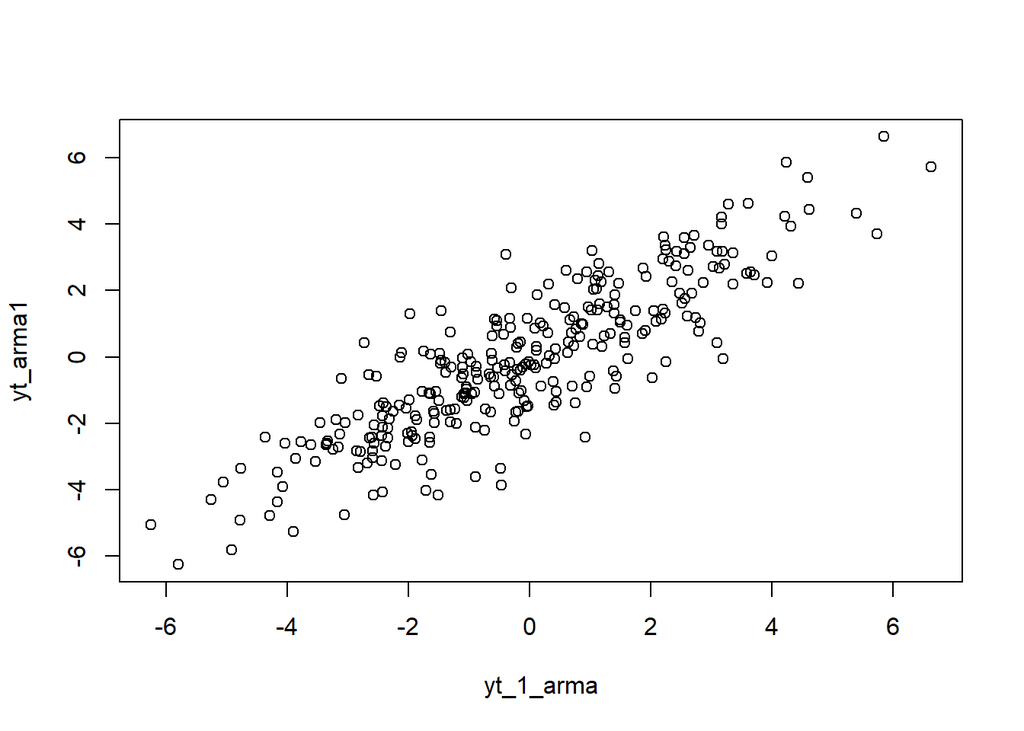

```r
#Scatterplot antara Yt dengan Yt-1
plot(y=yt_arma1,x=yt_1_arma)
```

```r
#Korelasi Yt dengan Yt-1
coryt1arma <- cor(yt_arma1,yt_1_arma)
coryt1arma
```

```
## [1] 0.8642291
```

##### Buat Scatterplot Model ARMA(2,2) antara Yt dengan Yt-2

```r
#Data untuk Yt dengan Yt-2
#Yt
yt_arma2 <- arma22[-c(1,2)]
yt_arma2
```

```
##   [1] -1.01862342  0.08795988  0.85152524  1.00224283 -0.57361523 -0.89246104
##   [7] -2.11264847  0.11930486  0.31902841  2.18209252  1.13877310  2.43428074
##  [13]  3.18631047  3.17391332  4.21207028  4.24102052  5.85290099  6.63312650
##  [19]  5.73466849  3.71133143  2.47838226  1.91956563  0.79512292  2.35368494
##  [25]  2.26035037  3.22030191  2.79537584  0.76342599  0.83093025  0.60221841
##  [31]  2.61518375  2.61318272  1.23880817  0.63261900  0.13236170  1.87812742
##  [37]  2.66275245  3.28615869  4.59309716  5.39638789  4.31441924  3.93260039
##  [43]  2.24148707  1.32958565  0.71051878 -0.88028778 -0.46942309 -3.86527314
##  [49] -3.05379657 -4.76965482 -3.36315895 -2.64761701 -0.53753095  1.08694499
##  [55]  2.30623825  2.87367858  2.23822519  3.35671899  2.19799461  2.95821582
##  [61]  3.36251081  3.13192956  2.67829043  1.92317602  2.41918045  2.73981089
##  [67]  1.18765765  2.25171598 -0.15196604  0.44072143 -1.36753884 -1.62598313
##  [73] -3.53268210 -3.15106707 -2.72337315  0.43325687  0.23304931  0.92577281
##  [79] -2.42335317 -1.76915084 -3.10476249 -0.64195061 -0.61338408  0.64079220
##  [85]  0.44388593 -1.04879145 -0.89758165 -3.60816485 -2.64756805 -2.43505213
```

[output cut: 35 more lines]

```r
#Yt-2
yt_2_arma <- arma22[-c(299,300)]
yt_2_arma
```

```
##   [1] -0.01483454 -0.14255724 -1.01862342  0.08795988  0.85152524  1.00224283
##   [7] -0.57361523 -0.89246104 -2.11264847  0.11930486  0.31902841  2.18209252
##  [13]  1.13877310  2.43428074  3.18631047  3.17391332  4.21207028  4.24102052
##  [19]  5.85290099  6.63312650  5.73466849  3.71133143  2.47838226  1.91956563
##  [25]  0.79512292  2.35368494  2.26035037  3.22030191  2.79537584  0.76342599
##  [31]  0.83093025  0.60221841  2.61518375  2.61318272  1.23880817  0.63261900
##  [37]  0.13236170  1.87812742  2.66275245  3.28615869  4.59309716  5.39638789
##  [43]  4.31441924  3.93260039  2.24148707  1.32958565  0.71051878 -0.88028778
##  [49] -0.46942309 -3.86527314 -3.05379657 -4.76965482 -3.36315895 -2.64761701
##  [55] -0.53753095  1.08694499  2.30623825  2.87367858  2.23822519  3.35671899
##  [61]  2.19799461  2.95821582  3.36251081  3.13192956  2.67829043  1.92317602
##  [67]  2.41918045  2.73981089  1.18765765  2.25171598 -0.15196604  0.44072143
##  [73] -1.36753884 -1.62598313 -3.53268210 -3.15106707 -2.72337315  0.43325687
##  [79]  0.23304931  0.92577281 -2.42335317 -1.76915084 -3.10476249 -0.64195061
##  [85] -0.61338408  0.64079220  0.44388593 -1.04879145 -0.89758165 -3.60816485
```

[output cut: 35 more lines]

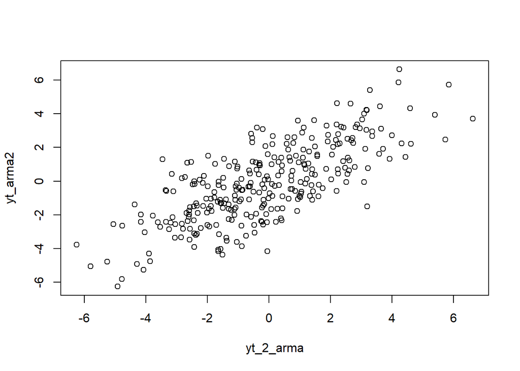

```r
#Scatterplot antara Yt dengan Yt-2
plot(y=yt_arma2,x=yt_2_arma)
```

```r
#Korelasi Yt dengan Yt-2
coryt2arma <- cor(yt_arma2,yt_2_arma)
coryt2arma
```

```
## [1] 0.7395845
```

##### Buat Scatterplot Model ARMA(2,2) antara Yt dengan Yt-3

```r
#Data untuk Yt dengan Yt-3
#Yt
yt_arma3 <- arma22[-c(1,2,3)]
yt_arma3
```

```
##   [1]  0.08795988  0.85152524  1.00224283 -0.57361523 -0.89246104 -2.11264847
##   [7]  0.11930486  0.31902841  2.18209252  1.13877310  2.43428074  3.18631047
##  [13]  3.17391332  4.21207028  4.24102052  5.85290099  6.63312650  5.73466849
##  [19]  3.71133143  2.47838226  1.91956563  0.79512292  2.35368494  2.26035037
##  [25]  3.22030191  2.79537584  0.76342599  0.83093025  0.60221841  2.61518375
##  [31]  2.61318272  1.23880817  0.63261900  0.13236170  1.87812742  2.66275245
##  [37]  3.28615869  4.59309716  5.39638789  4.31441924  3.93260039  2.24148707
##  [43]  1.32958565  0.71051878 -0.88028778 -0.46942309 -3.86527314 -3.05379657
##  [49] -4.76965482 -3.36315895 -2.64761701 -0.53753095  1.08694499  2.30623825
##  [55]  2.87367858  2.23822519  3.35671899  2.19799461  2.95821582  3.36251081
##  [61]  3.13192956  2.67829043  1.92317602  2.41918045  2.73981089  1.18765765
##  [67]  2.25171598 -0.15196604  0.44072143 -1.36753884 -1.62598313 -3.53268210
##  [73] -3.15106707 -2.72337315  0.43325687  0.23304931  0.92577281 -2.42335317
##  [79] -1.76915084 -3.10476249 -0.64195061 -0.61338408  0.64079220  0.44388593
##  [85] -1.04879145 -0.89758165 -3.60816485 -2.64756805 -2.43505213 -2.36259471
```

[output cut: 35 more lines]

```r
#Yt-3
yt_3_arma <- arma22[-c(298,299,300)]
yt_3_arma
```

```
##   [1] -0.01483454 -0.14255724 -1.01862342  0.08795988  0.85152524  1.00224283
##   [7] -0.57361523 -0.89246104 -2.11264847  0.11930486  0.31902841  2.18209252
##  [13]  1.13877310  2.43428074  3.18631047  3.17391332  4.21207028  4.24102052
##  [19]  5.85290099  6.63312650  5.73466849  3.71133143  2.47838226  1.91956563
##  [25]  0.79512292  2.35368494  2.26035037  3.22030191  2.79537584  0.76342599
##  [31]  0.83093025  0.60221841  2.61518375  2.61318272  1.23880817  0.63261900
##  [37]  0.13236170  1.87812742  2.66275245  3.28615869  4.59309716  5.39638789
##  [43]  4.31441924  3.93260039  2.24148707  1.32958565  0.71051878 -0.88028778
##  [49] -0.46942309 -3.86527314 -3.05379657 -4.76965482 -3.36315895 -2.64761701
##  [55] -0.53753095  1.08694499  2.30623825  2.87367858  2.23822519  3.35671899
##  [61]  2.19799461  2.95821582  3.36251081  3.13192956  2.67829043  1.92317602
##  [67]  2.41918045  2.73981089  1.18765765  2.25171598 -0.15196604  0.44072143
##  [73] -1.36753884 -1.62598313 -3.53268210 -3.15106707 -2.72337315  0.43325687
##  [79]  0.23304931  0.92577281 -2.42335317 -1.76915084 -3.10476249 -0.64195061
##  [85] -0.61338408  0.64079220  0.44388593 -1.04879145 -0.89758165 -3.60816485
```

[output cut: 35 more lines]

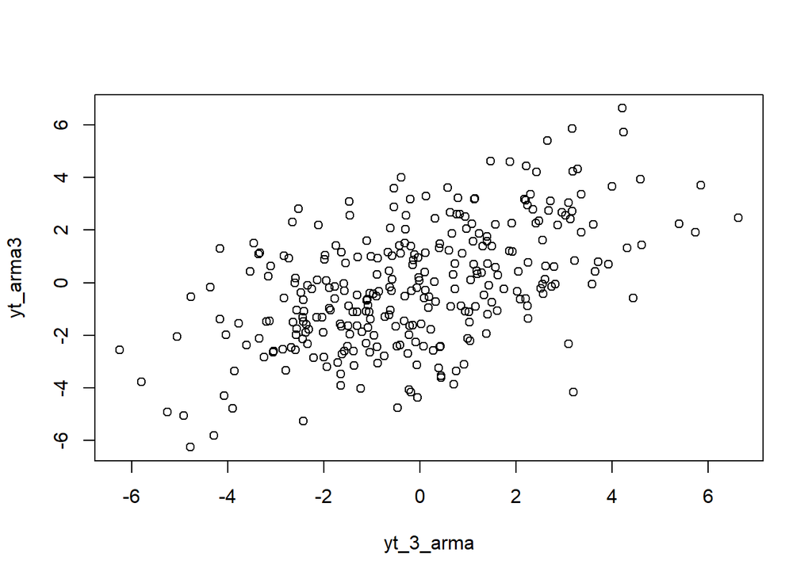

```r
#Scatterplot antara Yt dengan Yt-3
plot(y=yt_arma3,x=yt_3_arma)
```

```r
#Korelasi Yt dengan Yt-3
coryt3arma <- cor(yt_arma3,yt_3_arma)
coryt3arma
```

```
## [1] 0.5311153
```